# Logistic Regression - Bank_Personal_Loan

### Thera Bank Personal Loan Campaign Submitted By: Mayur Makadia

**Github: https://github.com/mayurmakadia1/UTAustin-PGP-AIML/tree/master/2-Supervised-Learning**

Data Description: The dataset contains data on 5000 customers. The data include customer demographic information (age, income, etc.), the customer's relationship with the bank (mortgage, securities account, etc.), and the customer response to the last personal loan campaign (Personal Loan). Among these 5000 customers, only 480 (= 9.6%) accepted the personal loan that was offered to them in the earlier campaign. Domain: Banking Context: This case is about a bank (Thera Bank) whose management wants to explore ways of converting its liability customers to personal loan customers (while retaining them as depositors). A campaign that the bank ran last year for liability customers showed a healthy conversion rate of over 9% success. This has encouraged the retail marketing department to devise campaigns with better target marketing to increase the success ratio with a minimal budget. Attribute Information:

- ID: Customer ID
- Age: Customer's age in completed years
- Experience: #years of professional experience
- Income: Annual income of the customer \$000
- ZIP Code: Home Address ZIP code.
- Family: Family size of the customer
- CCAvg: Avg. spending on credit cards per month \$000
- Education: Education Level. 1: Undergrad; 2: Graduate; 3: Advanced/Professional
- Mortgage: Value of house mortgage if any. \$000
- Personal Loan: Did this customer accept the personal loan offered in the last campaign?
- Securities Account: Does the customer have a securities account with the bank?
- CD Account: Does the customer have a certificate of deposit (CD) account with the bank?
- Online: Does the customer use internet banking facilities?
- Credit card: Does the customer use a credit card issued by the bank?

Learning Outcomes:

- Exploratory Data Analysis
- Preparing the data to train a model
- Training and making predictions using a classification model
- Model evaluation

Objective: The classification goal is to predict the likelihood of a liability customer buying personal loans.

## Task 1 - Import the datasets and libraries, check datatype, statistical summary, shape, null values or incorrect imputation.

```python
warnings.filterwarnings('ignore')
```

```python
#Load the libraries required
import numpy as np # linear algebra
import pandas as pd # data processing, CSV file I/O (e.g. pd.read_csv)
import matplotlib.pyplot as plt       # matplotlib.pyplot plots data
%matplotlib inline
import seaborn as sns
```

## Load and review data

```python
#read the dataset
bdata = pd.read_csv("Bank_Personal_Loan_Modelling.csv")
```

```python
#check the information about loaded dataset
bdata.shape # Check number of columns and rows in data frame
```

```
(5000, 14)
```

```python
#quick data review
bdata.head() # To check first 5 rows of data set
```

|  | ID | Age | Experience | Income | ZIP Code | Family | CCAvg | Education | Mortgage | Personal Loan | Securities Account | CD Account | Online | CreditCard |
| --- | --- | --- | --- | --- | --- | --- | --- | --- | --- | --- | --- | --- | --- | --- |
| 0 | 1 | 25 | 1 | 49 | 91107 | 4 | 1.6 | 1 | 0 | 0 | 1 | 0 | 0 | 0 |
| 1 | 2 | 45 | 19 | 34 | 90089 | 3 | 1.5 | 1 | 0 | 0 | 1 | 0 | 0 | 0 |
| 2 | 3 | 39 | 15 | 11 | 94720 | 1 | 1.0 | 1 | 0 | 0 | 0 | 0 | 0 | 0 |
| 3 | 4 | 35 | 9 | 100 | 94112 | 1 | 2.7 | 2 | 0 | 0 | 0 | 0 | 0 | 0 |
| 4 | 5 | 35 | 8 | 45 | 91330 | 4 | 1.0 | 2 | 0 | 0 | 0 | 0 | 0 | 1 |

```python
#Fix column names to remove spaces and make them all lower cases
bdata.columns = bdata.columns.str.strip().str.lower().str.replace(' ', '_')
```

```python
#check column names to make sure they are changed as expected
bdata.head() # To check first 5 rows of data set
```

|  | id | age | experience | income | zip_code | family | ccavg | education | mortgage | personal_loan | securities_account | cd_account | online | creditcard |
| --- | --- | --- | --- | --- | --- | --- | --- | --- | --- | --- | --- | --- | --- | --- |
| 0 | 1 | 25 | 1 | 49 | 91107 | 4 | 1.6 | 1 | 0 | 0 | 1 | 0 | 0 | 0 |
| 1 | 2 | 45 | 19 | 34 | 90089 | 3 | 1.5 | 1 | 0 | 0 | 1 | 0 | 0 | 0 |
| 2 | 3 | 39 | 15 | 11 | 94720 | 1 | 1.0 | 1 | 0 | 0 | 0 | 0 | 0 | 0 |
| 3 | 4 | 35 | 9 | 100 | 94112 | 1 | 2.7 | 2 | 0 | 0 | 0 | 0 | 0 | 0 |
| 4 | 5 | 35 | 8 | 45 | 91330 | 4 | 1.0 | 2 | 0 | 0 | 0 | 0 | 0 | 1 |

```python
#review data types for columns
print('===============================================================')
print('Data Types:')
print('===============================================================')
print(bdata.info())
```

```
===============================================================
Data Types:
===============================================================
<class 'pandas.core.frame.DataFrame'>
RangeIndex: 5000 entries, 0 to 4999
Data columns (total 14 columns):
 #   Column              Non-Null Count  Dtype
---  ------              --------------  -----
 0   id                  5000 non-null   int64
 1   age                 5000 non-null   int64
 2   experience          5000 non-null   int64
 3   income              5000 non-null   int64
 4   zip_code            5000 non-null   int64
 5   family              5000 non-null   int64
 6   ccavg               5000 non-null   float64
 7   education           5000 non-null   int64
 8   mortgage            5000 non-null   int64
 9   personal_loan       5000 non-null   int64
 10  securities_account  5000 non-null   int64
 11  cd_account          5000 non-null   int64
 12  online              5000 non-null   int64
 13  creditcard          5000 non-null   int64
dtypes: float64(1), int64(13)
memory usage: 547.0 KB
None
```

```python
print('===============================================================')
print('Shape:')
print('===============================================================')
print(bdata.shape)
```

```
===============================================================
Shape:
===============================================================
(5000, 14)
```

```python
print('===============================================================')
print('Statistical Summary:')
print('===============================================================')
print(bdata.describe().transpose())
```

```
===============================================================
Statistical Summary:
===============================================================
                     count          mean          std     min       25%  \
id                  5000.0   2500.500000  1443.520003     1.0   1250.75
age                 5000.0     45.338400    11.463166    23.0     35.00
experience          5000.0     20.104600    11.467954    -3.0     10.00
income              5000.0     73.774200    46.033729     8.0     39.00
zip_code            5000.0  93152.503000  2121.852197  9307.0  91911.00
family              5000.0      2.396400     1.147663     1.0      1.00
ccavg               5000.0      1.937938     1.747659     0.0      0.70
education           5000.0      1.881000     0.839869     1.0      1.00
mortgage            5000.0     56.498800   101.713802     0.0      0.00
personal_loan       5000.0      0.096000     0.294621     0.0      0.00
securities_account  5000.0      0.104400     0.305809     0.0      0.00
cd_account          5000.0      0.060400     0.238250     0.0      0.00
online              5000.0      0.596800     0.490589     0.0      0.00
creditcard          5000.0      0.294000     0.455637     0.0      0.00

                        50%       75%      max
id                   2500.5   3750.25   5000.0
age                    45.0     55.00     67.0
experience             20.0     30.00     43.0
income                 64.0     98.00    224.0
zip_code            93437.0  94608.00  96651.0
family                  2.0      3.00      4.0
ccavg                   1.5      2.50     10.0
education               2.0      3.00      3.0
mortgage                0.0    101.00    635.0
personal_loan           0.0      0.00      1.0
securities_account      0.0      0.00      1.0
cd_account              0.0      0.00      1.0
online                  1.0      1.00      1.0
creditcard              0.0      1.00      1.0
```

```python
print('===============================================================')
print('Null values:')
print('===============================================================')
print(bdata.isnull().sum())
```

```
===============================================================
Null values:
===============================================================
id                    0
age                   0
experience            0
income                0
zip_code              0
family                0
ccavg                 0
education             0
mortgage              0
personal_loan         0
securities_account    0
cd_account            0
online                0
creditcard            0
dtype: int64
```

## Task 2 - EDA: Study the data distribution in each attribute and target variable, share your findings

**Task 2.1 - Number of unique in each column?**

```python
# Age: Customer's age in completed years - DATA CHECK: SHOULD NOT BE LESS THAN 0
bdata.age.unique()
```

```
array([25, 45, 39, 35, 37, 53, 50, 34, 65, 29, 48, 59, 67, 60, 38, 42, 46,
       55, 56, 57, 44, 36, 43, 40, 30, 31, 51, 32, 61, 41, 28, 49, 47, 62,
       58, 54, 33, 27, 66, 24, 52, 26, 64, 63, 23], dtype=int64)
```

```python
# Experience: #years of professional experience - DATA CHECK: SHOULD NOT BE LESS THAN 0
bdata.experience.unique()
```

```
array([ 1, 19, 15,  9,  8, 13, 27, 24, 10, 39,  5, 23, 32, 41, 30, 14, 18,
       21, 28, 31, 11, 16, 20, 35,  6, 25,  7, 12, 26, 37, 17,  2, 36, 29,
        3, 22, -1, 34,  0, 38, 40, 33,  4, -2, 42, -3, 43], dtype=int64)
```

**Seems experience data has issues**, there are negative values (-1,-2,-3) in experience columns. This will be looked at during data preparation before executing logistic regression model

```python
# Income: Annual income of the customer \$000 - DATA CHECK: SHOULD NOT BE LESS THAN 0
bdata.income.unique()
```

```
array([ 49,  34,  11, 100,  45,  29,  72,  22,  81, 180, 105, 114,  40,
       112, 130, 193,  21,  25,  63,  62,  43, 152,  83, 158,  48, 119,
        35,  41,  18,  50, 121,  71, 141,  80,  84,  60, 132, 104,  52,
       194,   8, 131, 190,  44, 139,  93, 188,  39, 125,  32,  20, 115,
        69,  85, 135,  12, 133,  19,  82, 109,  42,  78,  51, 113, 118,
        64, 161,  94,  15,  74,  30,  38,   9,  92,  61,  73,  70, 149,
        98, 128,  31,  58,  54, 124, 163,  24,  79, 134,  23,  13, 138,
       171, 168,  65,  10, 148, 159, 169, 144, 165,  59,  68,  91, 172,
        55, 155,  53,  89,  28,  75, 170, 120,  99, 111,  33, 129, 122,
       150, 195, 110, 101, 191, 140, 153, 173, 174,  90, 179, 145, 200,
       183, 182,  88, 160, 205, 164,  14, 175, 103, 108, 185, 204, 154,
       102, 192, 202, 162, 142,  95, 184, 181, 143, 123, 178, 198, 201,
       203, 189, 151, 199, 224, 218], dtype=int64)
```

```python
# ZIP Code: Home Address ZIP code.
bdata.zip_code.unique()
```

```
array([91107, 90089, 94720, 94112, 91330, 92121, 91711, 93943, 93023,
       94710, 90277, 93106, 94920, 91741, 95054, 95010, 94305, 91604,
       94015, 90095, 91320, 95521, 95064, 90064, 94539, 94104, 94117,
       94801, 94035, 92647, 95814, 94114, 94115, 92672, 94122, 90019,
       95616, 94065, 95014, 91380, 95747, 92373, 92093, 94005, 90245,
       95819, 94022, 90404, 93407, 94523, 90024, 91360, 95670, 95123,
       90045, 91335, 93907, 92007, 94606, 94611, 94901, 92220, 93305,
       95134, 94612, 92507, 91730, 94501, 94303, 94105, 94550, 92612,
       95617, 92374, 94080, 94608, 93555, 93311, 94704, 92717, 92037,
       95136, 94542, 94143, 91775, 92703, 92354, 92024, 92831, 92833,
       94304, 90057, 92130, 91301, 92096, 92646, 92182, 92131, 93720,
       90840, 95035, 93010, 94928, 95831, 91770, 90007, 94102, 91423,
       93955, 94107, 92834, 93117, 94551, 94596, 94025, 94545, 95053,
       90036, 91125, 95120, 94706, 95827, 90503, 90250, 95817, 95503,
       93111, 94132, 95818, 91942, 90401, 93524, 95133, 92173, 94043,
```

[output cut: 38 more lines]

```python
# Family: Family size of the customer - SHOULD NOT BE LESS THAN 0
bdata.family.unique()
```

```
array([4, 3, 1, 2], dtype=int64)
```

```python
# CCAvg: Avg. spending on credit cards per month \$000 - DATA CHECK: SHOULD NOT BE LESS THAN 0
bdata.ccavg.unique()
```

```
array([ 1.6 ,  1.5 ,  1.  ,  2.7 ,  0.4 ,  0.3 ,  0.6 ,  8.9 ,  2.4 ,
        0.1 ,  3.8 ,  2.5 ,  2.  ,  4.7 ,  8.1 ,  0.5 ,  0.9 ,  1.2 ,
        0.7 ,  3.9 ,  0.2 ,  2.2 ,  3.3 ,  1.8 ,  2.9 ,  1.4 ,  5.  ,
        2.3 ,  1.1 ,  5.7 ,  4.5 ,  2.1 ,  8.  ,  1.7 ,  0.  ,  2.8 ,
        3.5 ,  4.  ,  2.6 ,  1.3 ,  5.6 ,  5.2 ,  3.  ,  4.6 ,  3.6 ,
        7.2 ,  1.75,  7.4 ,  2.67,  7.5 ,  6.5 ,  7.8 ,  7.9 ,  4.1 ,
        1.9 ,  4.3 ,  6.8 ,  5.1 ,  3.1 ,  0.8 ,  3.7 ,  6.2 ,  0.75,
        2.33,  4.9 ,  0.67,  3.2 ,  5.5 ,  6.9 ,  4.33,  7.3 ,  4.2 ,
        4.4 ,  6.1 ,  6.33,  6.6 ,  5.3 ,  3.4 ,  7.  ,  6.3 ,  8.3 ,
        6.  ,  1.67,  8.6 ,  7.6 ,  6.4 , 10.  ,  5.9 ,  5.4 ,  8.8 ,
        1.33,  9.  ,  6.7 ,  4.25,  6.67,  5.8 ,  4.8 ,  3.25,  5.67,
        8.5 ,  4.75,  4.67,  3.67,  8.2 ,  3.33,  5.33,  9.3 ,  2.75])
```

```python
# Education: Education Level. 1: Undergrad; 2: Graduate; 3: Advanced/Professional - SHOULD NOT BE OTHER THAN 1,2,3
bdata.education.unique()
```

```
array([1, 2, 3], dtype=int64)
```

```python
# Mortgage: Value of house mortgage if any. \$000 - DATA CHECK: SHOULD NOT BE LESS THAN 0
bdata.mortgage.unique()
```

```
array([  0, 155, 104, 134, 111, 260, 163, 159,  97, 122, 193, 198, 285,
       412, 153, 211, 207, 240, 455, 112, 336, 132, 118, 174, 126, 236,
       166, 136, 309, 103, 366, 101, 251, 276, 161, 149, 188, 116, 135,
       244, 164,  81, 315, 140,  95,  89,  90, 105, 100, 282, 209, 249,
        91,  98, 145, 150, 169, 280,  99,  78, 264, 113, 117, 325, 121,
       138,  77, 158, 109, 131, 391,  88, 129, 196, 617, 123, 167, 190,
       248,  82, 402, 360, 392, 185, 419, 270, 148, 466, 175, 147, 220,
       133, 182, 290, 125, 124, 224, 141, 119, 139, 115, 458, 172, 156,
       547, 470, 304, 221, 108, 179, 271, 378, 176,  76, 314,  87, 203,
       180, 230, 137, 152, 485, 300, 272, 144,  94, 208, 275,  83, 218,
       327, 322, 205, 227, 239,  85, 160, 364, 449,  75, 107,  92, 187,
       355, 106, 587, 214, 307, 263, 310, 127, 252, 170, 265, 177, 305,
       372,  79, 301, 232, 289, 212, 250,  84, 130, 303, 256, 259, 204,
       524, 157, 231, 287, 247, 333, 229, 357, 361, 294,  86, 329, 142,
       184, 442, 233, 215, 394, 475, 197, 228, 297, 128, 241, 437, 178,
       428, 162, 234, 257, 219, 337, 382, 397, 181, 120, 380, 200, 433,
       222, 483, 154, 171, 146, 110, 201, 277, 268, 237, 102,  93, 354,
       195, 194, 238, 226, 318, 342, 266, 114, 245, 341, 421, 359, 565,
       319, 151, 267, 601, 567, 352, 284, 199,  80, 334, 389, 186, 246,
       589, 242, 143, 323, 535, 293, 398, 343, 255, 311, 446, 223, 262,
       422, 192, 217, 168, 299, 505, 400, 165, 183, 326, 298, 569, 374,
       216, 191, 408, 406, 452, 432, 312, 477, 396, 582, 358, 213, 467,
       331, 295, 235, 635, 385, 328, 522, 496, 415, 461, 344, 206, 368,
       321, 296, 373, 292, 383, 427, 189, 202,  96, 429, 431, 286, 508,
       210, 416, 553, 403, 225, 500, 313, 410, 273, 381, 330, 345, 253,
       258, 351, 353, 308, 278, 464, 509, 243, 173, 481, 281, 306, 577,
       302, 405, 571, 581, 550, 283, 612, 590, 541], dtype=int64)
```

```python
# Personal Loan: Did this customer accept the personal loan offered in the last campaign? - SHOULD BE 0 or 1
bdata.personal_loan.unique()
```

```
array([0, 1], dtype=int64)
```

```python
# Securities Account: Does the customer have a securities account with the bank? - SHOULD BE 0 or 1
bdata.securities_account.unique()
```

```
array([1, 0], dtype=int64)
```

```python
# CD Account: Does the customer have a certificate of deposit (CD) account with the bank? - SHOULD BE 0 or 1
bdata.cd_account.unique()
```

```
array([0, 1], dtype=int64)
```

```python
# Online: Does the customer use internet banking facilities? - SHOULD BE 0 or 1
bdata.online.unique()
```

```
array([0, 1], dtype=int64)
```

```python
# Credit card: Does the customer use a credit card issued by the bank? - SHOULD BE 0 or 1
bdata.creditcard.unique()
```

```
array([0, 1], dtype=int64)
```

**Task 2.2 - Number of people with zero mortgage?**

```python
print("Number of people with zero mortgage = " + str(bdata[bdata.mortgage == 0].shape[0]))
```

```
Number of people with zero mortgage = 3462
```

**Task 2.3 - Number of people with zero credit card spending per month?**

```python
print("Number of people with zero credit card spending per month = " + str(bdata[bdata.ccavg == 0].shape[0]))
```

```
Number of people with zero credit card spending per month = 106
```

## Adjust dataset to drop the id column and assign type as category to relevant columns

```python
# ID column has all unique values and not a continous column and that would not provide any info to the algorithm
bdata.drop('id',axis=1,inplace=True)
```

```python
#Convert columns to categorical type based on column type and data wherever relevant
bdata['education'] = bdata['education'].astype('category')
bdata['zip_code'] = bdata['zip_code'].astype('category')
bdata['personal_loan'] = bdata['personal_loan'].astype('category')
bdata['securities_account'] = bdata['securities_account'].astype('category')
bdata['cd_account'] = bdata['cd_account'].astype('category')
bdata['online'] = bdata['online'].astype('category')
bdata['creditcard'] = bdata['creditcard'].astype('category')
```

```python
#check to ensure correct type is assigned
bdata.info()
```

```
<class 'pandas.core.frame.DataFrame'>
RangeIndex: 5000 entries, 0 to 4999
Data columns (total 13 columns):
 #   Column              Non-Null Count  Dtype
---  ------              --------------  -----
 0   age                 5000 non-null   int64
 1   experience          5000 non-null   int64
 2   income              5000 non-null   int64
 3   zip_code            5000 non-null   category
 4   family              5000 non-null   int64
 5   ccavg               5000 non-null   float64
 6   education           5000 non-null   category
 7   mortgage            5000 non-null   int64
 8   personal_loan       5000 non-null   category
 9   securities_account  5000 non-null   category
 10  cd_account          5000 non-null   category
 11  online              5000 non-null   category
 12  creditcard          5000 non-null   category
dtypes: category(7), float64(1), int64(5)
memory usage: 297.8 KB
```

**Task 2.4 - Value counts of all categorical columns.**

```python
#Task 2.4 - Value counts of Education
bdata['education'].value_counts(normalize=True)
```

```
1    0.4192
3    0.3002
2    0.2806
Name: education, dtype: float64
```

```python
#Task 2.4 - Value counts of Education
n_1 = len(bdata.loc[bdata['education'] == 1])
n_2 = len(bdata.loc[bdata['education'] == 2])
n_3 = len(bdata.loc[bdata['education'] == 3])
print('==============================================')
print('Education')
print('==============================================')
print("Number of cases where education is Undergrad: {0} ({1:2.2f}%)".format(n_1, (n_1 / (n_1 + n_2 + n_3)) * 100 ))
print("Number of cases where education is Graduate: {0} ({1:2.2f}%)".format(n_2, (n_2 / (n_1 + n_2 +n_3)) * 100))
print("Number of cases where education is Advanced/Professional: {0} ({1:2.2f}%)".format(n_3, (n_3 / (n_1 + n_2 +n_3)) * 100))
```

```
==============================================
Education
==============================================
Number of cases where education is Undergrad: 2096 (41.92%)
Number of cases where education is Graduate: 1403 (28.06%)
Number of cases where education is Advanced/Professional: 1501 (30.02%)
```

```python
#Task 2.4 - Value counts of Personal Loan
bdata['personal_loan'].value_counts(normalize=True)
```

```
0    0.904
1    0.096
Name: personal_loan, dtype: float64
```

```python
#Task 2.4 - Value counts of Personal Loan
n_true = len(bdata.loc[bdata['personal_loan'] == 1])
n_false = len(bdata.loc[bdata['personal_loan'] == 0])
print('==============================================')
print('Personal Loan')
print('==============================================')
print("Number of true cases: {0} ({1:2.2f}%)".format(n_true, (n_true / (n_true + n_false)) * 100 ))
print("Number of false cases: {0} ({1:2.2f}%)".format(n_false, (n_false / (n_true + n_false)) * 100))
```

```
==============================================
Personal Loan
==============================================
Number of true cases: 480 (9.60%)
Number of false cases: 4520 (90.40%)
```

```python
#Task 2.4 - Value counts of Securities Account
bdata['securities_account'].value_counts(normalize=True)
```

```
0    0.8956
1    0.1044
Name: securities_account, dtype: float64
```

```python
#Task 2.4 - Value counts of Securities Account
n_true = len(bdata.loc[bdata['securities_account'] == 1])
n_false = len(bdata.loc[bdata['securities_account'] == 0])
print('==============================================')
print('Securities Account')
print('==============================================')
print("Number of true cases: {0} ({1:2.2f}%)".format(n_true, (n_true / (n_true + n_false)) * 100 ))
print("Number of false cases: {0} ({1:2.2f}%)".format(n_false, (n_false / (n_true + n_false)) * 100))
```

```
==============================================
Securities Account
==============================================
Number of true cases: 522 (10.44%)
Number of false cases: 4478 (89.56%)
```

```python
#Task 2.4 - Value counts of CD Account
bdata['cd_account'].value_counts(normalize=True)
```

```
0    0.9396
1    0.0604
Name: cd_account, dtype: float64
```

```python
#Task 2.4 - Value counts of CD Account
n_true = len(bdata.loc[bdata['cd_account'] == 1])
n_false = len(bdata.loc[bdata['cd_account'] == 0])
print('==============================================')
print('CD Account')
print('==============================================')
print("Number of true cases: {0} ({1:2.2f}%)".format(n_true, (n_true / (n_true + n_false)) * 100 ))
print("Number of false cases: {0} ({1:2.2f}%)".format(n_false, (n_false / (n_true + n_false)) * 100))
```

```
==============================================
CD Account
==============================================
Number of true cases: 302 (6.04%)
Number of false cases: 4698 (93.96%)
```

```python
#Task 2.4 - Value counts of Online
bdata['online'].value_counts(normalize=True)
```

```
1    0.5968
0    0.4032
Name: online, dtype: float64
```

```python
#Task 2.4 - Value counts of Online
n_true = len(bdata.loc[bdata['online'] == 1])
n_false = len(bdata.loc[bdata['online'] == 0])
print('==============================================')
print('Online')
print('==============================================')
print("Number of true cases: {0} ({1:2.2f}%)".format(n_true, (n_true / (n_true + n_false)) * 100 ))
print("Number of false cases: {0} ({1:2.2f}%)".format(n_false, (n_false / (n_true + n_false)) * 100))
```

```
==============================================
Online
==============================================
Number of true cases: 2984 (59.68%)
Number of false cases: 2016 (40.32%)
```

```python
#Task 2.4 - Value counts of CREDIT CARD
bdata['creditcard'].value_counts(normalize=True)
```

```
0    0.706
1    0.294
Name: creditcard, dtype: float64
```

```python
#Task 2.4 - Value counts of CREDIT CARD
n_true = len(bdata.loc[bdata['creditcard'] == 1])
n_false = len(bdata.loc[bdata['creditcard'] == 0])
print('==============================================')
print('Credit Card')
print('==============================================')
print("Number of true cases: {0} ({1:2.2f}%)".format(n_true, (n_true / (n_true + n_false)) * 100 ))
print("Number of false cases: {0} ({1:2.2f}%)".format(n_false, (n_false / (n_true + n_false)) * 100))
```

```
==============================================
Credit Card
==============================================
Number of true cases: 1470 (29.40%)
Number of false cases: 3530 (70.60%)
```

```python
#Task 2.4 - Value counts of Zip code
bdata['zip_code'].value_counts(normalize=True)
```

```
94720    0.0338
94305    0.0254
95616    0.0232
90095    0.0142
93106    0.0114
          ...
92694    0.0002
94965    0.0002
94970    0.0002
91024    0.0002
9307     0.0002
Name: zip_code, Length: 467, dtype: float64
```

**Task 2.5 - Univariate and Bivariate**

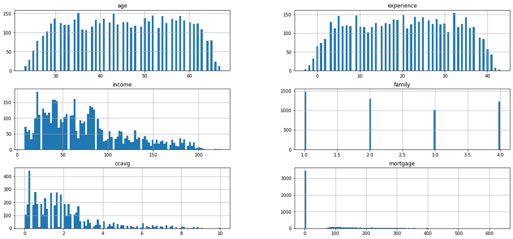

```python
#Task 2.5-Univariate graph plots
columns = list(bdata)[0:]
bdata[columns].hist(stacked=False, bins=100, figsize=(20,45), layout=(14,2));
```

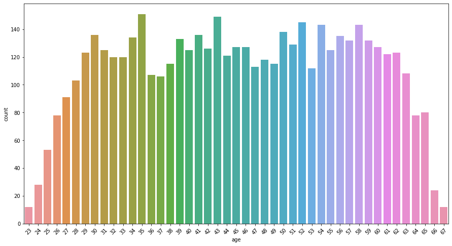

```python
plt.figure(figsize=(15,8))
sns.countplot(bdata['age'])
plt.xticks(rotation=45)
plt.show()
```

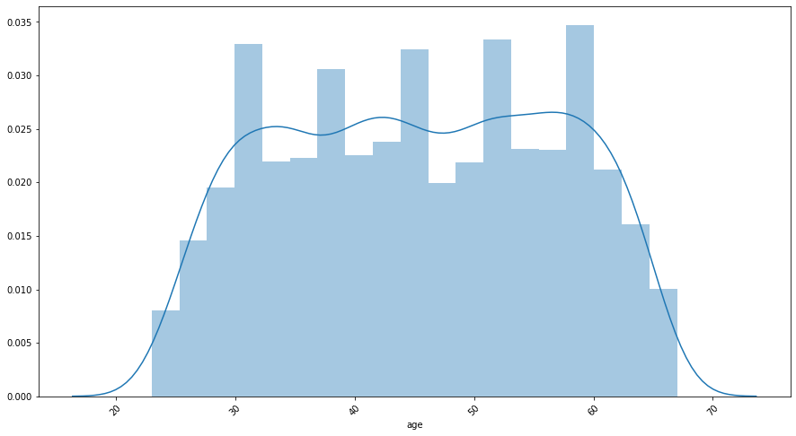

```python
plt.figure(figsize=(15,8))
sns.distplot(bdata['age'],kde=True)
plt.xticks(rotation=45)
plt.show()
```

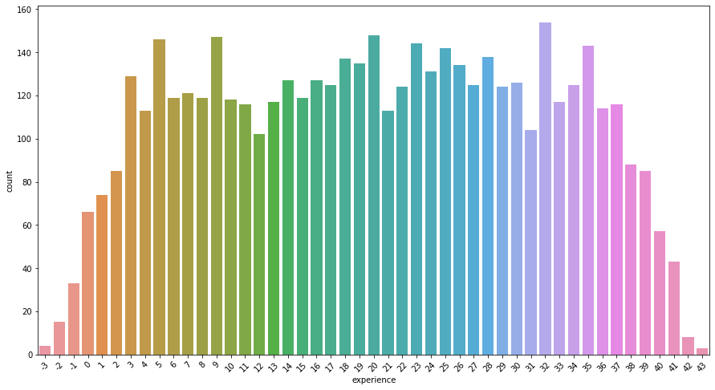

```python
plt.figure(figsize=(15,8))
sns.countplot(bdata['experience'])
plt.xticks(rotation=45)
plt.show()
```

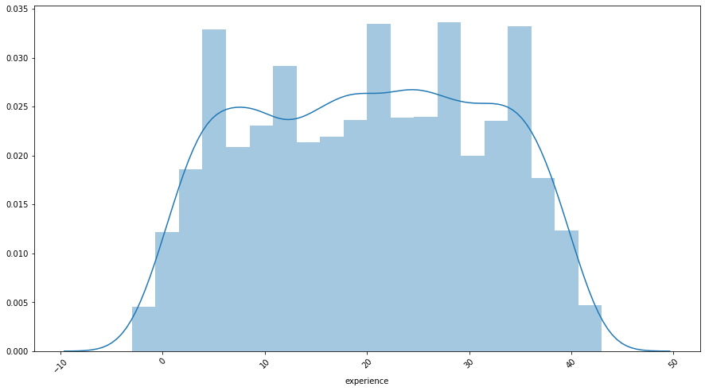

```python
plt.figure(figsize=(15,8))
sns.distplot(bdata['experience'],kde=True)
plt.xticks(rotation=45)
plt.show()
```

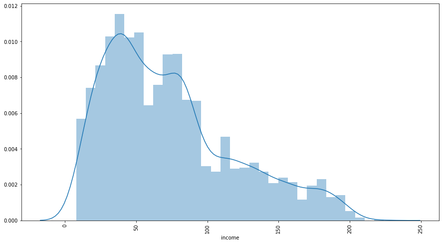

```python
plt.figure(figsize=(15,8))
sns.distplot(bdata['income'],kde=True)
plt.xticks(rotation=90)
plt.show()
```

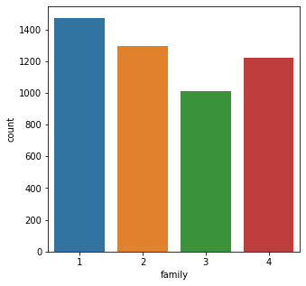

```python
plt.figure(figsize=(5,5))
sns.countplot(bdata['family'])
plt.show()
```

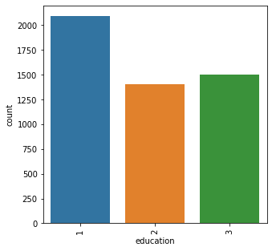

```python
plt.figure(figsize=(5,5))
sns.countplot(bdata['education'])
plt.xticks(rotation=90)
plt.show()
```

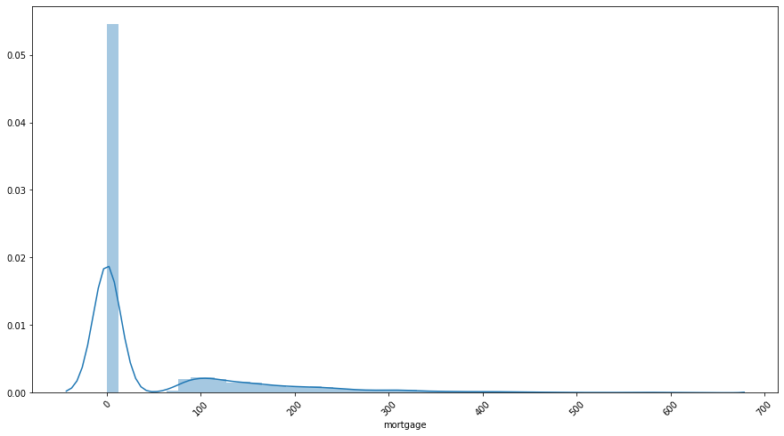

```python
plt.figure(figsize=(15,8))
sns.distplot(bdata['mortgage'],kde=True)
plt.xticks(rotation=45)
plt.show()
```

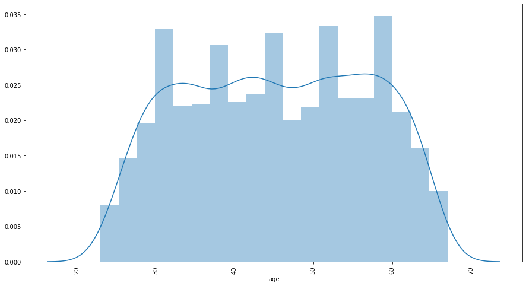

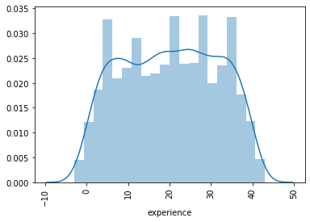

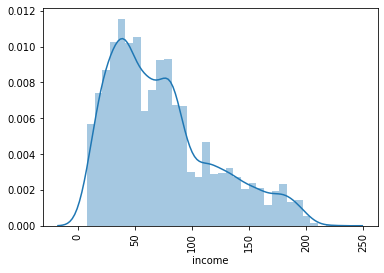

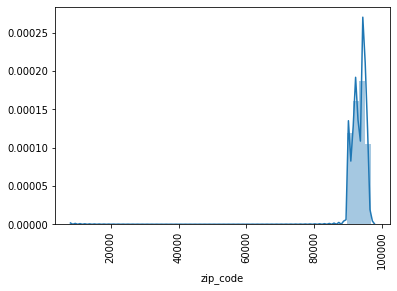

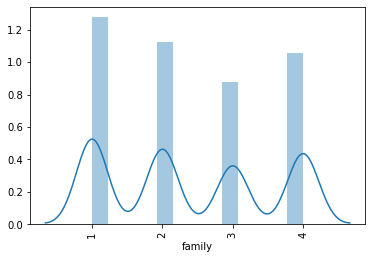

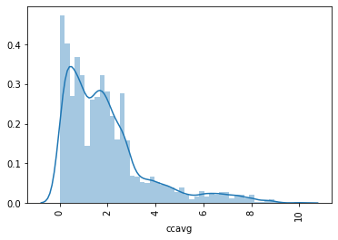

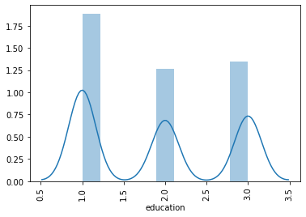

```python
# distplot for continous columns
plt.figure(figsize=(15,8))
for i in ['age','experience','income','zip_code','family','ccavg','education']:
    sns.distplot(bdata[i])
    plt.xticks(rotation=90)
    plt.show()
```

## Identify Correlation in data

```python
bdata.corr() # It will show correlation matrix
```

|  | age | experience | income | family | ccavg | mortgage |
| --- | --- | --- | --- | --- | --- | --- |
| age | 1.000000 | 0.994215 | -0.055269 | -0.046418 | -0.052012 | -0.012539 |
| experience | 0.994215 | 1.000000 | -0.046574 | -0.052563 | -0.050077 | -0.010582 |
| income | -0.055269 | -0.046574 | 1.000000 | -0.157501 | 0.645984 | 0.206806 |
| family | -0.046418 | -0.052563 | -0.157501 | 1.000000 | -0.109275 | -0.020445 |
| ccavg | -0.052012 | -0.050077 | 0.645984 | -0.109275 | 1.000000 | 0.109905 |
| mortgage | -0.012539 | -0.010582 | 0.206806 | -0.020445 | 0.109905 | 1.000000 |

```python
# Function for correlation
def plot_corr(df, size=11):
    corr = df.corr()
    fig, ax = plt.subplots(figsize=(size, size))
    ax.matshow(corr)
    plt.xticks(range(len(corr.columns)), corr.columns)
    plt.yticks(range(len(corr.columns)), corr.columns)
    plt.xticks(rotation=90)
    for (i, j), z in np.ndenumerate(corr):
        ax.text(j, i, '{:0.1f}'.format(z), ha='center', va='center')
```

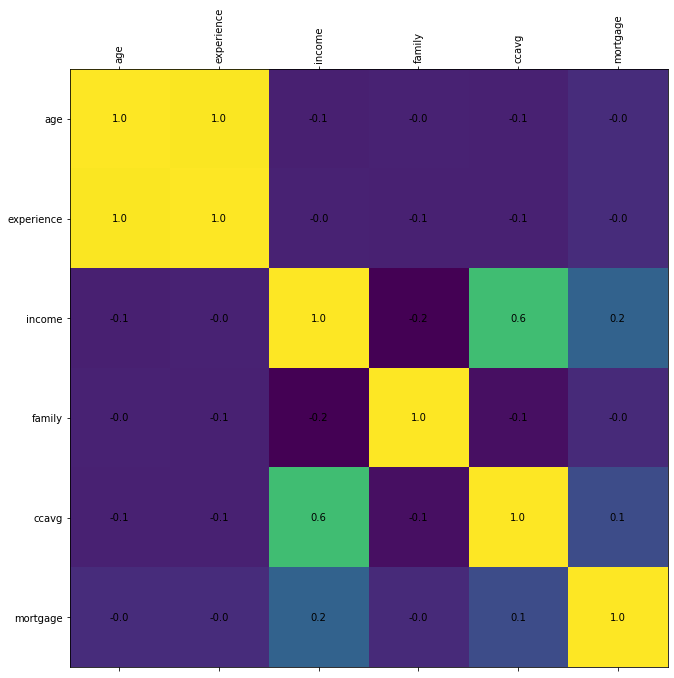

```python
plot_corr(bdata)
```

In above plot yellow color represents maximum correlation and blue color represents minimum correlation. We can see experience and age are correlated. Also there is some correlation between income and ccavg.

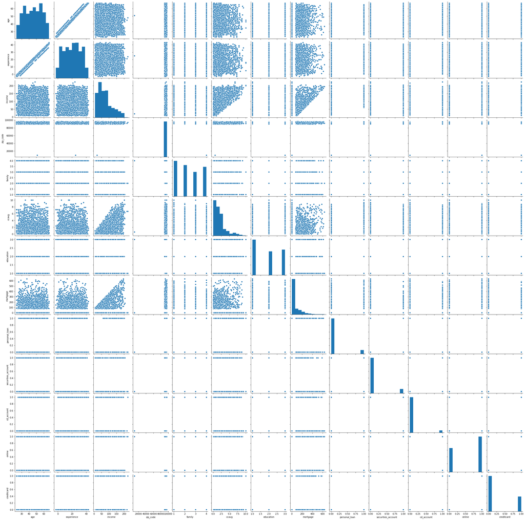

```python
sns.pairplot(bdata)
```

```python
# Let us look at the target column which is 'personal_loan' to understand how the data is distributed amongst
#the various values
bdata.groupby(["personal_loan"]).mean()
```

| personal_loan | age | experience | income | family | ccavg | mortgage |
| --- | --- | --- | --- | --- | --- | --- |
| 0 | 45.367257 | 20.132301 | 66.237389 | 2.373451 | 1.729009 | 51.789381 |
| 1 | 45.066667 | 19.843750 | 144.745833 | 2.612500 | 3.905354 | 100.845833 |

```python
bdata.groupby(["personal_loan"]).median()
```

| personal_loan | age | experience | income | family | ccavg | mortgage |
| --- | --- | --- | --- | --- | --- | --- |
| 0 | 45.0 | 20.0 | 59.0 | 2.0 | 1.4 | 0.0 |
| 1 | 45.0 | 20.0 | 142.5 | 3.0 | 3.8 | 0.0 |

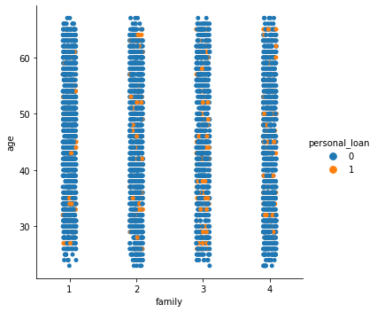

```python
g = sns.catplot(x="family", y="age", hue="personal_loan", data=bdata)
```

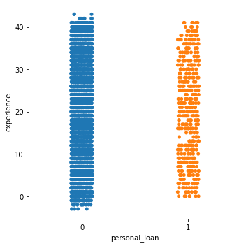

```python
g = sns.catplot(x="personal_loan", y="experience", data=bdata)
```

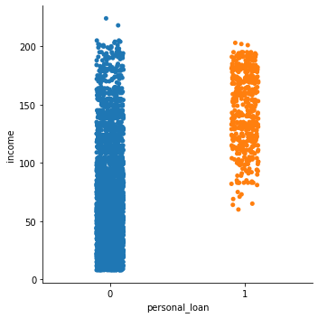

```python
g = sns.catplot(x="personal_loan", y="income", data=bdata)
```

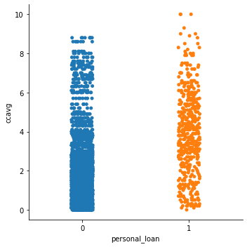

```python
g = sns.catplot(x="personal_loan", y="ccavg", data=bdata)
```

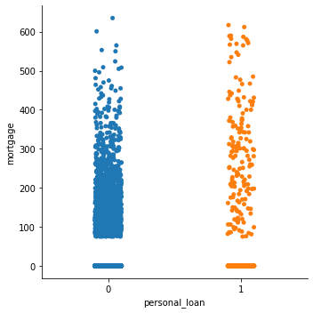

```python
g = sns.catplot(x="personal_loan", y="mortgage", data=bdata)
```